# Does Hybridisation Pay? A Systematic Review of Metaheuristic Optimisation and Machine Learning Hybrids in Pavement Engineering (2005–2026)

Authors

Affiliations

Seyed Saber Naseralavi

Shahid Bahonar University of Kerman

Ali Reza Ghanizadeh

Sirjan University of Technology

Published

August 9, 2026

Abstract

Keywords

pavement engineering, metaheuristic optimisation, machine learning, hybrid models, systematic review, methodological rigour

> **Draft status.** This file renders to PDF, Word and HTML from one source. Sections marked *PLACEHOLDER* are not yet written. Every citation resolves against `references.bib`, which is generated from `data/seed_bibliography.csv`; a citation key that is not in the verified database fails the render rather than passing silently.

# 1 Introduction

Pavement engineering has, over the past decade, adopted a specific and recurring rhetorical move: an optimisation algorithm is coupled to a learning model, the coupled system is shown to out-predict some comparator, and the coupling itself is offered as the paper’s contribution. Grey wolf optimisers, whale optimisation, teaching-learning-based optimisation, forensic-based investigation, dipper-throated optimisation and dozens of similarly named metaheuristics have each, in turn, been married to a neural network, a support vector machine, an extreme learning machine or a gradient-boosted ensemble, and the resulting hybrid reported as an advance over the base learner alone. The pattern is now common enough that “hybrid” is arguably the single most frequent claim of novelty in the data-driven pavement literature of the 2020s.

This review asks a question that the pattern itself rarely answers: **relative to what, exactly, is the hybrid better?** A hybrid model is compared, almost without exception, against a base learner running with default or lightly-adjusted settings. It is compared far more rarely against the same base learner tuned by a conventional procedure under a comparable search budget — the baseline that would isolate what the metaheuristic actually contributed. Where that comparison has been made, in the small number of cases we have located so far, the hybrid’s advantage over a properly tuned baseline shrinks, and sometimes reverses. Zeiada et al. (Zeiada et al., 2025) individually tuned eight learners, including deep architectures, against the Witczak and Hirsch mechanistic models for asphalt dynamic modulus; the winner was a tuned bagging ensemble, not a hybrid and not a deep network. Azam et al. (Azam et al., 2022) compared six swarm-optimised variants of one base learner against each other and report top-three results within a fraction of a percentage point of R<sup>2</sup> — a separation well inside what a different random seed would produce — but never against a conventionally tuned version of the same learner, so no premium can be read from the paper at all. These two studies, sitting side by side in the same sub-field, illustrate the gap this review sets out to measure at scale: **how often is the hybridisation premium — the gain attributable to the coupling itself, over a fairly tuned baseline — actually reported, and how large is it when it is?**

Answering this requires solving a prior problem, which turns out to be nontrivial in its own right: **finding the studies.** A literature search built on the word “hybrid” misses a substantial share of the relevant work, because many qualifying studies describe themselves with the vocabulary of optimisation rather than of hybridity — “optimised”, “improved”, “novel X–Y” or simply the two algorithm names side by side. Alhussan et al.’s dipper-throated-optimisation random forest for pothole classification is a case in point: widely cited, structurally a textbook metaheuristic-on-learner hybrid, and retrievable by a search on algorithm names but not reliably by a search on the word “hybrid” itself. Section 2 describes the algorithm-driven search design this observation motivates, and reports, as one of the review’s descriptive findings, what share of the eligible literature would have been missed by a label-driven search alone.

## 1.1 Positioning relative to the existing review literature

Prior reviews of artificial-intelligence methods in pavement engineering are numerous but occupy different territory, summarised in Figure 1. The most direct predecessor, Yang et al. (Yang et al., 2021), catalogues where neural networks have been applied across the pavement lifecycle; it stops at the MLP/CNN/RNN generation and does not treat hybridisation, optimisation coupling or methodological rigour as organising questions. Domain-specific vision surveys (Cao et al., 2020; Gopalakrishnan, 2018; Hou et al., 2020) cover distress detection in depth but do not extend to materials, structural evaluation or network-level decisions. Three very recent contributions come closer to the diagnosis this review develops, and each must be distinguished on its own terms rather than folded quietly into a single “gap” claim. Tamagusko and Ferreira name standardisation, interpretability and replicability as open problems specifically for roughness prediction on flexible pavements. M’harzi Alaoui et al. (M’harzi Alaoui et al., 2026) describe an “interpretability paradox” and a lab-to-field gap across 180 soil-stabilisation studies. Closest of all, Jweihan (Jweihan, 2026) conducts a PRISMA-ScR scoping review of 163 studies on explainable and interpretable machine learning specifically in asphalt pavement engineering, and proposes a five-layer appraisal framework — data provenance, model performance, explanation quality, physical plausibility, decision utility — that overlaps conceptually with more than one domain of the instrument this review proposes in §12. The honest distinction is not that this territory is unoccupied; it is that Jweihan’s review is organised around explainability as the object of study and conducted at scoping-review depth (breadth of coverage, not per-study methodological coding), whereas the present review is organised around hybridisation — the optimiser-learner coupling itself — as the object of study, uses a full systematic protocol with per-study rigour coding (leakage risk, external validation, baseline strength, search-budget parity), and reports the coded audit as a quantified premium rather than as a coverage synthesis. Interpretability is one of several PAVE-ML domains in this review, not its organising question; the two instruments are complementary rather than competing, and §12 states explicitly where PAVE-ML’s interpretability items and Jweihan’s five-layer framework agree and where they diverge. What none of these three contributions does — and what remains this review’s distinguishing claim — is define hybridity structurally rather than lexically so that algorithm-vocabulary studies are not missed, code a consistent rigour rubric across the full range of pavement sub-domains rather than one at a time, and convert the resulting evidence into a quantified premium and a reusable reporting instrument built around that specific construct.

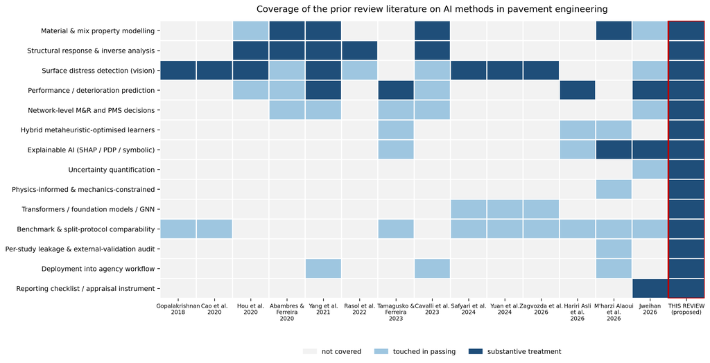

Figure 1: Coverage of the prior review literature on artificial-intelligence methods in pavement engineering. Scoring: 2 = substantive dedicated treatment, 1 = touched in passing, 0 = absent. “This review” is scored on stated scope, to be verified against the completed manuscript at submission.

## 1.2 Contributions

This review makes four contributions. First, a **structural rather than lexical** definition of hybridity (§2.3) and an algorithm-driven search protocol built to retrieve studies regardless of how their authors chose to describe them. Second, a **taxonomy of seven hybridisation types** (H1–H7, §4), each with a stated theoretical justification and a characteristic failure mode, replacing the field’s undifferentiated use of “hybrid” as a single label. Third, an empirical estimate of the **hybridisation premium** — the performance gain attributable to hybridisation once the comparison is made against a fairly tuned baseline — reported as a distribution across the coded corpus rather than as a single number, since most studies do not report the comparison required to compute it at all (§9). Fourth, a reporting and appraisal instrument, **PAVE-ML**, extending a general data-driven-pavement-model checklist with four items specific to hybrid pipelines (§12), so that the next study in this field can report what this review finds missing from most of the last two decades of it.

# 2 Review methodology

*Full draft in `docs/02_MANUSCRIPT_S2_methodology.md`; transferred here section by section as each is finalised.*

## 2.1 Scope and framing question

This review asks how much of the performance gain attributed to hybridisation in the pavement literature survives a fair comparison against a properly tuned base learner. The question differs from “where has hybridisation been applied” — the question earlier surveys answer — in that it requires reading each study for a specific comparison rather than for topical coverage, and it requires a definition of hybridity that does not depend on the authors’ own labelling (§2.3).

## 2.2 Information sources and search

Records were identified from OpenAlex, Scopus, Web of Science Core Collection and Semantic Scholar, with backward and forward snowballing from the 16 prior reviews listed in Table 1. The window runs from 1 January 2005 to 30 June 2026.

Table 1: Prior reviews of artificial-intelligence methods in pavement engineering, with the territory each occupies.

| Review | Year | Venue | Territory |
| --- | --- | --- | --- |
| Gopalakrishnan | 2018 | Data | distress-detection |
| Cao et al. | 2020 | IEEE Access | distress-detection |
| Hou et al. | 2020 | Engineering | structural-evaluation/distress-detection |
| Abambres et al. | 2020 | TechRxiv (preprint) | all |
| Yang et al. | 2021 | J. Traffic Transp. Eng. (Engl. Ed.) | all |
| Rasol et al. | 2022 | Constr. Build. Mater. | structural-evaluation |
| Cavalli et al. | 2023 | J. Road Eng. | all |
| Tamagusko et al. | 2023 | Infrastructures | performance-prediction |
| Deng et al. | 2023 | J. Infrastruct. Preserv. Resil. | performance-prediction |
| Yuan et al. | 2024 | Remote Sensing | distress-detection |
| Safyari et al. | 2024 | Sensors | distress-detection |
| Khatti et al. | 2025 | Soils and Rocks | materials |
| M’harzi Alaoui et al. | 2026 | J. Umm Al-Qura Univ. Eng. Archit. | materials |
| Jweihan | 2026 | Applied System Innovation | materials/performance-prediction |
| Zagvozda et al. | 2026 | Adv. Civ. Archit. Eng. | distress-detection |
| Hariri Asli et al. | 2026 | J. Infrastruct. Preserv. Resil. | performance-prediction |

## 2.3 Eligibility

**Structural definition of hybridity.** A study is in scope if its predictive pipeline couples two or more components drawn from different methodological families, at least one of which is a learned data-driven model, where the coupling is claimed or demonstrated to affect predictive performance. Three operational clarifications resolve most borderline cases. Hyperparameter search counts as hybridisation only when the search procedure is itself a metaheuristic or a surrogate-based optimiser (e.g. particle swarm optimisation, a genetic algorithm, Bayesian optimisation, a tree-structured Parzen estimator); manual tuning and exhaustive grid search do not qualify a study as hybrid, though both are recorded, since they are the baseline against which the premium (§9) is measured. An ensemble of models from a single family (e.g. a random forest) is not a hybrid; a stacked ensemble with heterogeneous base learners is (type H5, §4). Self-description is irrelevant in both directions: a study is included or excluded on the structure of its pipeline, never on whether the authors used the word “hybrid”.

This structural test was necessary, not a refinement for its own sake. A pilot search restricted to hybrid-labelled vocabulary failed to retrieve at least one widely cited, structurally qualifying study — a dipper-throated-optimisation random forest for pothole classification (Alhussan et al., 2022) — while an algorithm-name-driven search retrieved it immediately. The same algorithm-name search, however, drifted heavily into adjacent domains (geopolymer concrete, rock-burst prediction, blasting-induced flyrock, and battery remaining-useful-life studies all appeared for generic swarm-optimisation queries), which is why every query in the harvesting protocol (`analysis/harvest_openalex.py`) carries a mandatory, hard-filtered pavement-domain term rather than relying on the optimisation vocabulary alone.

**Peer review and language.** Peer-reviewed journal articles and full conference papers in English are eligible. Preprints are excluded unless a peer-reviewed version is traced; where cited as grey literature (e.g. Latifi et al. (2021)) that status is stated explicitly.

**Exclusions that shaped the corpus.** Three exclusions recur often enough to state here rather than only in the PRISMA log. Non-neural, non-metaheuristic machine learning without any coupled component — a single tuned random forest or gradient- boosted tree, for instance — is not itself in scope, but is retained in a context set where it serves as a same-paper tuned-baseline comparator (this is, in fact, where several of the review’s most useful premium comparisons come from — see Zeiada et al. (2025) and Guo et al. (2025)). Studies where a metaheuristic and a learner are each named in the title but run as separate, non-interacting competing models rather than coupled into one pipeline are excluded from the hybrid corpus proper under the structural test above, and are flagged as an instance of the vocabulary trap in reverse — the label suggests a hybrid that the method does not deliver (e.g. Hanandeh (2022), titled around “genetic algorithm and artificial neural networks” but reporting the two as independently competing models). Reinforcement-learning formulations for network-level maintenance and rehabilitation decisions (e.g. Yao et al. (2022)) coordinate a learned policy with a simulated or predicted environment in a way that does not map cleanly onto the H1–H7 taxonomy, which is built around single-prediction pipelines; these are retained as context for §9 and §11 rather than coded into the taxonomy.

# 3 Bibliometric landscape

> **Status note.** The figures in this section describe the seed corpus (`data/seed_bibliography.csv`, n = 131 primary studies) assembled during protocol development and taxonomy design, not the completed systematic harvest. The full bibliometric analysis — publication trajectory, architecture share over time, country co-authorship, venue concentration — is deferred to the completed corpus and is not fabricated here from a partial sample. What follows is reported explicitly as a seed-corpus snapshot.

Of the 131 primary studies coded so far, Figure 2 shows their distribution across the seven hybridisation types defined in §4. A substantial share — 27 of 131 — do not qualify as hybrid under the structural test in §2.3 despite frequent adjacency to hybrid work in citation networks and, in a few cases, despite carrying “hybrid” or an optimiser name in the title while running the two components as separate, non-interacting models (§2.3). This is an early indication, not yet a corpus-wide estimate, of how much daylight exists between the field’s vocabulary and its actual methodological content; §9 returns to the consequence of that gap for the premium estimate.

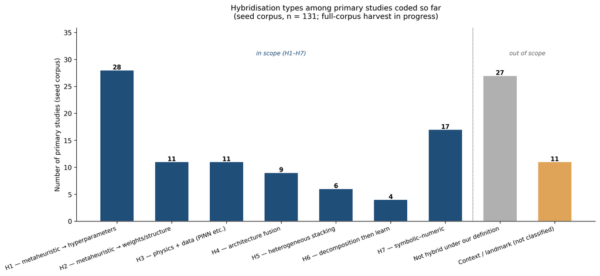

Figure 2: Distribution of hybridisation types among primary studies coded in the seed corpus.

Figure 3 shows the same primary studies by publication year. The visible concentration after 2020 is consistent with the review’s opening claim that hybridisation-as-novelty accelerated through the current decade, but the figure must be read as what it is — the yield of targeted, taxonomy-driven searches run during protocol development, not a random or exhaustive sample — and it is captioned accordingly rather than presented as a bibliometric trend claim the seed corpus cannot support on its own.

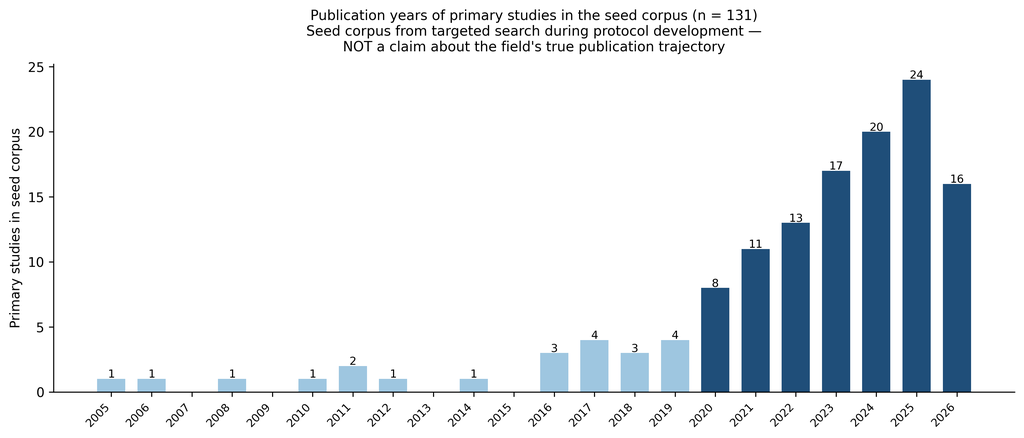

Figure 3: Publication years of primary studies in the seed corpus. This is a targeted-search yield, not a claim about the field’s true publication trajectory; the completed harvest will supersede this figure.

# 4 Taxonomy of hybridisation

The field’s literature treats “hybrid” as a single, undifferentiated label. This flattens together couplings with different theoretical justifications and, correspondingly, different characteristic failure modes — a metaheuristic searching a hyperparameter space is a different claim from a metaheuristic searching a weight space, and a different claim again from a physics-constrained loss function. Table 2 sets out the seven types this review distinguishes and codes against.

Table 2: Taxonomy of hybridisation in data-driven pavement models (H1–H7).

| Type | Coupling | Theoretical justification | Characteristic failure mode |
| --- | --- | --- | --- |
| **H1** | Metaheuristic → hyperparameters | Searches a non-convex, discrete hyperparameter space that gradient methods cannot address | Compared against an untuned base learner, so the reported gain is the tuning, not the metaheuristic |
| **H2** | Metaheuristic → weights / structure | Escapes local minima of backpropagation; permits non-differentiable objectives | Vastly more function evaluations than the baseline receives, with no compute-parity reporting |
| **H3** | Physics + data (PINN, mechanistic residual, transfer function as loss) | Constrains the solution to a mechanically admissible manifold; aids under data scarcity | Physics-term weight tuned on the test set; constraint too weak to bind in practice |
| **H4** | Architecture fusion (e.g. CNN+transformer, two-stream) | Complementary inductive biases – local texture and long-range context together | Gains confounded with parameter count and training budget rather than the fusion itself |
| **H5** | Heterogeneous stacking / blending | Decorrelated errors across model families reduce variance | Meta-learner trained on in-fold predictions; leakage through the stacking layer |
| **H6** | Signal decomposition then learn (VMD, EMD, CEEMDAN, wavelet) | Separates scales the learner would otherwise have to disentangle unaided | Decomposition fitted on the full series before the temporal split – the most common severe leakage in this family |
| **H7** | Symbolic–numeric (GEP, MGGP, EPR + a numeric optimiser) | Yields a closed-form, inspectable expression rather than an opaque model | Expression complexity uncontrolled; an overfit equation is then read as if it were physics |

Two coding notes follow directly from applying this taxonomy to the seed corpus. First, a single study can legitimately receive more than one code — Ghorbani et al. (2020) fits both a GA-derived symbolic equation (H7-adjacent) and an ANN whose weights are set by the same GA (H2) on the same data, which is precisely the kind of within-paper comparison §9 is built to exploit. Second, several studies that use metaheuristic or architecture-fusion vocabulary in their titles fail the structural test on inspection — Hanandeh (2022) names both a genetic algorithm and an artificial neural network but reports them as independently competing models rather than a coupled pipeline, and is coded `none` rather than any of H1–H7 as a result. Both notes matter for the same reason: the taxonomy is applied to what a pipeline *does*, not to what its title or abstract *calls* it.

Reinforcement-learning approaches to network-level maintenance-and-rehabilitation policy (Latifi et al., 2021; Yao et al., 2022) sit adjacent to this taxonomy but are not coded into it: they couple a learned policy to a simulated or predicted environment in a way that does not map onto the single-prediction-pipeline structure H1–H7 assumes. They are retained as context for the decision-consequence discussion in §11 rather than folded into the hybridisation-type counts in §3.

# 5 Hybrid models in material and mix modelling

Material-property modelling is the sub-domain where the seed corpus shows the heaviest concentration of H1 (metaheuristic-tuned hyperparameters) and H7 (symbolic–numeric) activity, and it is also where the tuned-baseline problem identified in §9 is most visible, because the target properties — resilient modulus, dynamic modulus, unconfined compressive strength, air-void content — are exactly the properties for which competitor mechanistic or empirical models already exist and are routinely, though not universally, available for comparison.

The resilient-modulus literature illustrates both the promise and the recurring weakness. Ghorbani et al. (Ghorbani et al., 2020) fit two related models on the same repeated-load triaxial dataset — a genetic-algorithm-derived symbolic equation and an ANN whose weights the same genetic algorithm sets (H2) — and report the hybrid ANN-GA model as the more accurate of the two, a rare instance in the corpus of a true head-to-head comparison between two hybridisation types on identical data rather than between a hybrid and an unspecified baseline. Azam et al. (Azam et al., 2022) instead compare six swarm-optimised variants of a single base learner (LSSVM) against one another; the top three separate by RMSE values of 6.72, 6.78 and 6.79 MPa and R<sup>2</sup> values of 0.942, 0.940 and 0.940 — a spread well inside what a different random seed would plausibly produce — and none is compared against a conventionally tuned, non-hybrid LSSVM, so no premium is computable from the paper as published (§9). Kaloop et al. (Kaloop et al., 2019) report a similar optimiser-held-constant, learner-varied design (PSO-ANN vs. PSO-ELM vs. kernel-ELM), useful for isolating base-learner choice but not, by itself, for isolating the optimiser’s contribution.

The clearest positive exemplar in this section is not a hybrid at all in the H1–H7 sense: Zeiada et al. (Zeiada et al., 2025) individually tune eight learners, including deep architectures, and benchmark every one of them against the Witczak 1-40D and Hirsch mechanistic models for dynamic modulus. Under that design, the winner is a tuned bagging ensemble — not a hybrid and not a deep network — which is precisely the finding a hybridisation-premium framework should produce when tuning is held fair across all competitors, and it is the paper this review returns to repeatedly (§1, §9) as the standard the rest of the sub-domain should be read against.

Duan (Duan, 2024) supplies a genuinely mixed case worth reading in full rather than reducing to a single verdict, because full-text verification surfaces both a real strength and a real gap in the same paper. On the positive side, the metaheuristic-tuned BKA-XGBoost model (H1) reports its own search budget explicitly (population 10, 20 iterations) and, unusually for this corpus, checks its own reliability by reassembling the dataset ten times and reporting performance across all ten combinations rather than a single best run — exactly the repeated-run practice PAVE-ML item 12c asks for. The paper also states outright, discussing four comparator models drawn from the literature, that “direct performance comparisons are unconvincing” because those models were fitted on different datasets — an author-acknowledged version of the cross-study comparability problem this review is built around, and one of the only such acknowledgements found in the corpus so far. On the other side of the same paper: the nine within-paper comparator models are given listed parameter settings but no stated search budget, so whether they received tuning effort comparable to BKA-XGBoost’s own cannot be confirmed from the text — and no mechanistic resistance-modulus model is included as a comparator, so baseline_strength codes moderate rather than strong despite the nine-model comparison looking exhaustive at a glance. The lesson is the same one §11 draws more generally: a paper can do real, citable work toward some PAVE-ML items while leaving others exactly as unaddressed as the rest of the field.

On the symbolic side, Ghanizadeh et al. (Ghanizadeh et al., 2024) fit a TLBO-optimised evolutionary polynomial regression and multi-gene genetic programming model (H7) for asphalt air-void evolution, producing a closed-form, inspectable expression rather than an opaque predictor — a property that recurs as a theme in §10’s discussion of what interpretability should mean for a validated, not merely a post-hoc-explained, model.

# 6 Hybrid models in structural evaluation and inverse analysis

Structural evaluation and inverse analysis — principally back-calculation of layer moduli from deflection data — is the sub-domain with the strongest example of external validation in the entire seed corpus, and for that reason anchors much of the argument in §11 as well as this section. Elbagalati et al. (Elbagalati et al., 2017) train an ANN model on a Louisiana continuous-deflection programme and evaluate it on an independent Minnesota programme; R<sup>2</sup> falls only from 0.73 to 0.72 across that transfer, which is the benchmark against which the field’s more typical 0.99-on-random-holdout results should be read, and the paper is cited repeatedly in this review precisely because it is the exception rather than the rule.

Ghanizadeh and colleagues’ own back-calculation work traces a coherent five-year arc that this section follows in sequence: an ANN back-calculation model with Garson and connection-weight sensitivity analysis (Ghanizadeh et al., 2020) establishes the baseline single-architecture approach with post-hoc interpretability; METABACKCAL (Ghanizadeh et al., 2025) replaces the neural surrogate with a metaheuristic-driven inverse solver directly (H2, in the sense that the metaheuristic operates on the inverse problem itself rather than on a learned model’s hyperparameters), and is released as a named tool — one of very few entries in the seed corpus with deployment evidence beyond a closed-form equation. Reading the two together sets up a natural question for the completed review: does the metaheuristic-driven solver in the later paper report an accuracy gain over the earlier ANN surrogate under a comparable computational budget, and if so, of what size? That comparison is identified but not yet completed, since it requires a full-text extraction from both papers rather than the abstract-level record currently in the database.

Pasupunuri, Thom and Li (Pasupunuri et al., 2024) supply this review’s clearest H3 (physics-informed) exemplar, embedding the MEPDG roughness model itself as the physics-loss term of a PINN for jointed plain concrete pavement roughness — the single clearest published case in the corpus of a mechanics-constrained learner in pavement engineering, and a useful counterpoint to the purely data-driven H1/H2 work that dominates the rest of this section.

# 7 Hybrid models in performance prediction

Performance and deterioration prediction — international roughness index, rutting, cracking, faulting, remaining service life — is the sub-domain most heavily dependent on the Long-Term Pavement Performance (LTPP) database in the seed corpus, and correspondingly the sub-domain where the near-duplicate-substrate problem named in the review methodology is most concrete rather than abstract. A single overlapping author team — Alnaqbi, Zeiada and Al-Khateeb, joined variously by Abuzwidah, Hamad and Barakat across different papers — has published at least eight studies located so far, all drawing on what appears to be the same approximately 33-section, 385–395-observation continuously-reinforced-concrete- pavement substrate from LTPP, each pairing a different metaheuristic (chiefly PSO or a genetic algorithm) with a different base learner (chiefly SVR or a gradient boosting machine) to predict a different single target variable — international roughness index (Alnaqbi et al., 2025f, 2025e, 2025a), longitudinal cracking (Alnaqbi et al., 2025d, 2025b), spalling (Alnaqbi et al., 2024), friction number (Alnaqbi et al., 2026), and punchouts (Alnaqbi et al., 2025c) — each reported as a separate publication, each evaluated by five-fold cross-validation, and each reporting R<sup>2</sup> in the 0.90–0.99 range. Two pairs within this set differ from one another only in which metaheuristic tunes the same base learner on the same target and the same substrate: Alnaqbi et al. (2025d) (PSO-GBM) and Alnaqbi et al. (2025b) (GA-GBM) both predict longitudinal cracking; Alnaqbi et al. (2025f) (PSO-SVR), Alnaqbi et al. (2025e) (PSO-GBM) and Alnaqbi et al. (2025a) (GA-SVR) all predict IRI on what the papers describe as the identical 395-observation, 33-section pool.

None of this is concealed — Alnaqbi et al. (2025c)‘s own reference list cites six other papers from the same series, so the pattern is not hidden, only undiscussed. Full-text verification of the first two published members of the series, Alnaqbi et al. (2025f) and Alnaqbi et al. (2025d), confirms rather than merely suspects the leakage concern, and confirms it identically in both papers rather than once. The first states its partitioning plainly as “the dataset was split into 5 subsets, and the model was trained and tested 5 times, each time using a different subset as the test set and the remaining subsets as the training set”; the second, on a different target variable but the identical 395-observation, 33-section substrate, states it just as plainly as “five equal-sized subsets were randomly selected from the dataset… the training and testing subsets were switched around in each iteration.” Both are random splits at the observation level, and neither methods section — read in full, not excerpted — mentions grouping by the 33 physical CRCP sections the observations are drawn from. With roughly twelve observations per section on average, an ungrouped random split places multiple, highly correlated records from the same physical section on both sides of most folds — precisely the leakage pathway the PAVE-ML rule for `leakage_risk` (§12) is written to catch. Both papers’ own Limitations or Future Directions sections separately confirm the absence of external validation in their own words — the first stating outright that “no independent testing was done using additional datasets,” the second listing “external dataset validation” among unmet future work — which independently confirms the `external_validation: no` coding under the criterion in §2.3 twice over, rather than by the silence-as-absence convention alone. Worth noting for what it reveals about how such concerns are currently addressed in this literature: the first paper anticipates an overfitting objection and defends against it by observing that RMSE stays within a narrow band across folds (0.02791–0.06422) — but fold-to-fold consistency is not evidence against the leakage pathway just described, since every fold would share the same section-level contamination and so would be expected to perform similarly whether or not the model has learned anything section-specific. Figure 4 makes the mechanism concrete: with roughly twelve observations per section, an ungrouped random assignment (Panel A) all but guarantees that most sections contribute records to more than one fold, so a model can be trained on 10–11 of a section’s 12 observations and then “tested” on the 12th — a near-duplicate, spatially correlated record rather than a genuinely unseen one. A section-grouped assignment (Panel B), which the reviewed papers’ methods sections do not describe using, holds each section entirely within one fold, so the test fold contains no information the model could have seen during training.

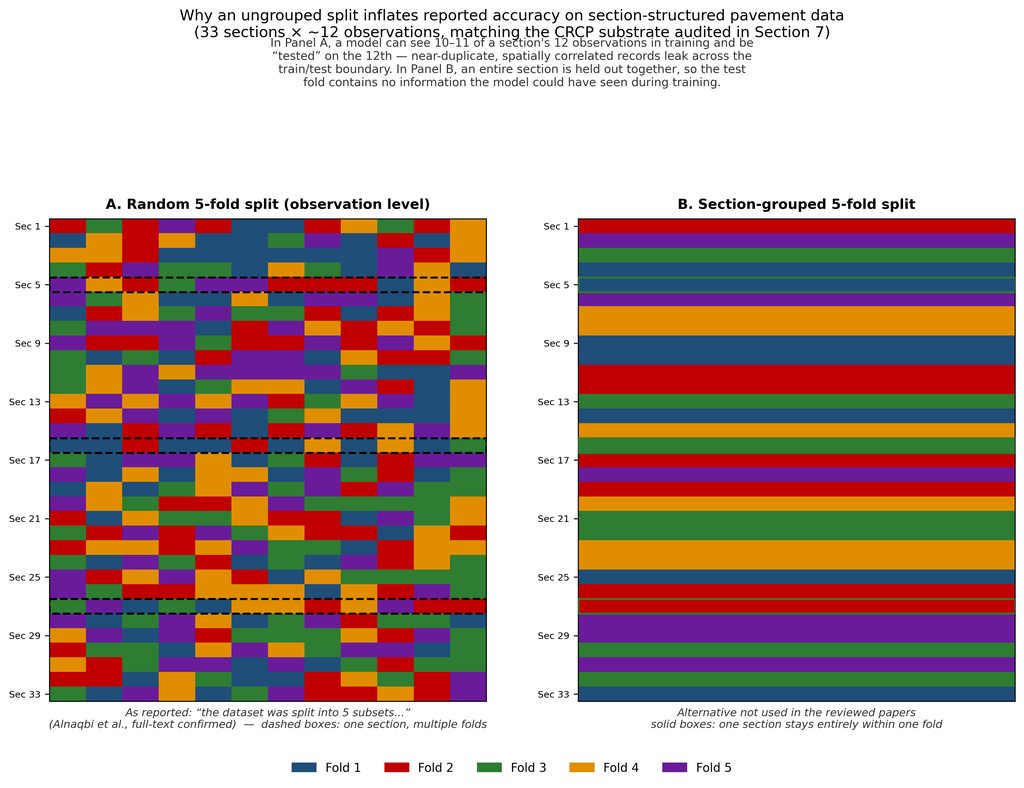

Figure 4: Random versus section-grouped 5-fold cross-validation on a 33-section, ~12-observation-per-section substrate matching the CRCP data audited in this section. Panel A reproduces the partitioning Alnaqbi et al. (2025f)’s methods section describes; Panel B shows the section-grouped alternative not used in the reviewed papers.

Both papers also describe z-score normalisation, imputation and outlier removal within a single “data preprocessing” stage that textually precedes the cross-validation description, with no statement in either that these steps were refit inside each fold rather than computed once over the full pool. The remaining six papers in the series are coded `high` risk pending the same full-text check now completed, identically, for the first two; nothing in their abstracts suggests a different partitioning procedure was used, and two independent confirmations make that a considerably stronger prior than one.

Two further pieces of evidence extend the pattern beyond one author team, and one of them is now full-text confirmed rather than ambiguous. Xiao et al.’s TPE-CatBoost faulting model (Xiao et al., 2023), read in full, resolves its own ambiguity definitively: the paper’s Boruta feature-selection step is performed in Section 3 (“Data Preparation”), applied to the full 160-observation pool, and only in Section 4 (“Model Construction”) does an 80/20 train-test split appear — meaning Boruta selected the six variables the final model uses with the benefit of information from what later became the test partition. This is a different leakage mechanism from the CRCP series above — a real held-out test set exists here, contaminated only by feature selection performed before the split, rather than an entirely ungrouped cross-validation — and the paper’s own conclusion attributes part of its headline result directly to the contaminated step: the six-variable model improves R<sup>2</sup> by 0.007 over the seventeen-variable version, “attributed to the capability of Boruta to identify relevant variables.” The two mechanisms, read together, make the point this review is built to make more sharply than either alone: `leakage_risk` in PAVE-ML (§12) catches structurally different failures — no partition grouping in one case, preprocessing fitted before the partition in the other — under a single item, which is exactly why the item is framed around the outcome (does information from the test set influence training) rather than around one specific mechanism. A citation search while verifying this paper separately surfaced a second, seemingly independent overlapping-author cluster — Wang, Xiao and Liu (Wang et al., 2023), sharing two of the same three surnames as the TPE-CatBoost paper — publishing a separate improved-XGBoost model for rigid pavement IRI on what appears to be a related LTPP substrate. Whether this is a second, independent instance of the single-target-per-paper pattern or reflects overlapping personnel with the first cluster is a question the completed harvest, not this seed corpus, is positioned to answer.

Two things distinguish this section’s treatment of the near-duplicate-substrate problem from a general methodological aside. First, the count is now large enough — eight identified papers, two of them full-text-confirmed rather than only abstract-flagged, likely more once the full harvest is complete — that the completed review can report a systematic, partly-verified finding rather than gesture at a concern: what fraction of this specific author team’s substrate-sharing series groups its cross-validation folds by section, once every remaining paper’s methods section has been read with the same care as the first. Second, the pattern usefully illustrates a broader point this review returns to in §11: an unlimited supply of near-identical papers reporting R<sup>2</sup> above 0.90 on the same underlying 33 physical objects, whatever its cause, produces exactly the appearance of a mature and thoroughly validated sub-field that the rigour audit is designed to test.

Deng and Shi’s practitioner-facing review of rutting models (Deng and Shi, 2023) adds a data point this review’s own audit cannot generate on its own: a survey of which rutting-prediction models highway agencies actually report using in practice. That detail belongs with the deployment-evidence discussion in §9 and §12 as one of the only direct looks, anywhere in the surrounding literature, at the demand side of the deployment gap this review otherwise infers only from what published papers do not report.

# 8 Physics-informed, fusion, stacking, decomposition and symbolic hybrids

The five hybridisation types beyond direct metaheuristic-hyperparameter coupling (H3–H7) are less numerous in the seed corpus than H1, but each supplies at least one clear exemplar worth setting out in detail because each illustrates a distinct failure mode that a reader unfamiliar with the taxonomy in §4 would not otherwise anticipate.

**H4, architecture fusion**, is best represented in the seed corpus by four vision and one network-level study discussed in detail below, plus four further CNN–transformer crack-detection studies added from a 2026 harvest pass (Deng et al., 2025; Guo et al., 2023; Luo et al., 2023; Zhang et al., 2026) that were search- or title-confirmed rather than full-text verified — together they show the CNN+transformer fusion pattern recurring from 2023 through 2026 rather than appearing once. The best-cited of the four, Guo et al.’s Swin-Transformer-encoder, attention-augmented-UperNet-decoder network (Guo et al., 2023), reports 102 citations at the time of writing — more than any other H4 record in the corpus — and an explicit within-paper comparison against CNN-only baselines, which is the staged-ablation pattern this section otherwise has to go looking for. Sun et al.’s PCDETR (Sun et al., 2023) fuses a Swin-Transformer and a ResNet backbone for pavement crack detection and reports near-identical average precision on the authors’ own dataset and on COCO (45.6% vs. 45.8%) — a similarity close enough across two very different image domains to warrant scrutiny rather than to be read at face value as evidence of robust transfer. Alshawabkeh et al. (Alshawabkeh et al., 2023) and Elhariri et al. (Elhariri et al., 2020) both couple deep and hand-crafted feature extraction with a metaheuristic feature-selection stage (jointly H1 and H4 under the taxonomy in §4), and both report a staged, within-paper ablation — deep features alone, then with the added classifier, then with the added optimiser — which is the design §9’s premium construct depends on and which most H1 studies elsewhere in the corpus do not provide. At the network rather than the image level, Pan, Du and Parlikad’s PaveGNet (Pan et al., 2025) fuses a graph module encoding inter-section topology with a temporal module encoding distress evolution, and is, at the time of writing, this review’s clearest example of the staged-ablation design done well: independently substituting the temporal, spatial and exogenous-variable components and reporting the ranking-error contribution of each (a fall from 9.005% to 2.670% for the full model against a spatiotemporal graph-convolution baseline). It is a useful positive counterpoint to place beside the H1 studies earlier in this section, and is the closest the seed corpus comes to network-level, rather than single-section, hybridisation evidence.

**H6, decomposition then learn**, was reported through the previous phase of this review as the one taxonomy type with no confirmed pavement-specific exemplar in the seed corpus, after two independent, differently worded search sweeps failed to find one. That was an honest report of what those two sweeps actually covered, not a structural claim about the literature, and it has not survived a third, larger pass: a 2026 harvest search identified Kaloop et al.’s wavelet–OP-ELM model for rigid pavement roughness (Kaloop et al., 2020), whose own abstract states plainly that “Optimally Pruned Extreme Learning Machine (OP-ELM) and Wavelet analysis are integrated” and benchmarks the coupling against plain OP-ELM, a conventional ANN and a regression baseline on LTPP data — a genuine, abstract-confirmed H6 case. A second, more tentative candidate (Zhang et al., 2025) pairs ensemble empirical mode decomposition with a downstream predictor for pavement modulus, though the retrievable abstract snippet does not name that downstream model explicitly, so it is coded provisionally pending full-text confirmation. Neither record’s leakage risk is known: both publishers blocked automated full-text access — the same failure mode recorded against a separate, earlier verification attempt on a ScienceDirect-hosted paper (documented in the database, not repeated here) — so whether the decomposition step was fitted before or after the train/test split — the exact H6 failure mode this taxonomy names — remains unread rather than assumed either way. A follow-up search pass the same day found two further, older H6 records that a single query had missed: Nejad and Zakeri’s paired 2011 studies (Moghadas Nejad and Zakeri, 2011; Nejad and Zakeri, 2011) each couple a wavelet-domain decomposition (wavelet–Radon transform in one, wavelet transform alone in the other) to a distinct trained neural-network classifier for pavement distress recognition — the same two authors, the same journal and year, two related but architecturally different H6 designs rather than one. H6 in this corpus is therefore no longer a single exemplar but a small evidence base of four records spanning 2011 to 2025, which changes what can honestly be said about it: not “does H6 exist in pavement engineering” (yes), but “how often is it done safely,” which full-text verification of these four is now positioned to answer. A fifth, superficially similar record is worth naming precisely because it is *not* H6: Ayenu-Prah and Attoh-Okine’s bidimensional empirical-mode-decomposition study (Ayenu-Prah and Attoh-Okine, 2008) — at 170 citations, the best-cited record this pass touched — pairs BEMD with a Sobel edge detector, a fixed classical operator, not a trained model, so it fails the structural test in §2.3 despite matching every keyword an automated screen would use to flag it as H6. It is the cleanest available illustration of the type’s boundary: decomposition followed by a fixed operator is not H6; decomposition followed by something that learns from data is. The corrected finding is therefore that H6 is rare but not absent, that its absence in earlier phases reflected search coverage rather than a property of the literature, and that the field’s own vocabulary (“wavelet-based,” “EMD-based”) does not reliably distinguish the two cases — exactly the vocabulary problem §1 opens with, recurring one taxonomy type later. The research agenda in §13 is updated accordingly.

**H3 (physics-informed)** and **H7 (symbolic–numeric)** are each introduced in §6 and §5 respectively (Ghanizadeh et al., 2024; Ghorbani et al., 2020; Pasupunuri et al., 2024) and are not repeated here in full; both recur in §10’s discussion of what a validated, mechanically consistent model should be able to claim about its own interpretability that a purely post-hoc explanation of an unvalidated model cannot.